# H9_RPE Dataset Integration

## Notebook setup

```r
library(Seurat)
library(tidyverse)
library(ggpubr)
library(ComplexHeatmap)
```

## Assigning clusters to analysed datasets

Set control to resolution 0.6 and aged to 0.7. These values were determined from the clustree generated in each sample’s analysis.

```r
# Load objects
control_obj <- readRDS("/Volumes/LACIE/RPE_scRNA/PUBLISHED/H9_RPE_YOUNG_Analysed_Object.rds")
aged_obj <- readRDS("/Volumes/LACIE/RPE_scRNA/PUBLISHED/H9_RPE_AGED_Analysed_Object.rds")

# Set resolution
control_obj[["seurat_clusters"]] <- control_obj[["SCT_snn_res.0.6"]]
control_obj[["condition"]] <- "Young"
Idents(control_obj) <- "seurat_clusters"

aged_obj[["seurat_clusters"]] <- aged_obj[["SCT_snn_res.0.7"]]
aged_obj[["condition"]] <- "Aged"
Idents(aged_obj) <- "seurat_clusters"
```

### Cluster sizes

```r
# Extract cluster data from Seurat objects
control_metadata <- FetchData(control_obj, vars = c("condition", "seurat_clusters"))
aged_metadata <- FetchData(aged_obj, vars = c("condition", "seurat_clusters"))

# Tabulate cluster counts
control_cluster_counts <- as.data.frame(table(control_metadata$seurat_clusters))
aged_cluster_counts <- as.data.frame(table(aged_metadata$seurat_clusters))

# Combine cluster counts
cluster_counts <- left_join(control_cluster_counts, aged_cluster_counts, by = "Var1")
colnames(cluster_counts) <- c("Cluster", "Control", "Aged")
cluster_counts
```

| Cluster | Control | Aged |
| --- | --- | --- |
| 0 | 2219 | 851 |
| 1 | 1873 | 815 |
| 2 | 1872 | 521 |
| 3 | 1683 | 461 |
| 4 | 1656 | 420 |
| 5 | 1073 | 410 |
| 6 | 871 | 235 |
| 7 | 584 | 170 |
| 8 | 169 | 155 |
| 9 | 152 | 97 |

[output cut: 2 more lines]

### Find integration anchors

We will use CCA to identify the anchors and the SCTransform integration workflow to integrate the two datasets. Note that this method harmonizes the residuals generated by the SCTransform normalization method for each sample, and then combines them into one matrix.

```r
# Edit globals because we need these for some reason
options(future.globals.maxSize = 1600 * 1024^3)
gene_list <- intersect(rownames(control_obj), rownames(aged_obj))
object_list <- list(Control = control_obj, Aged = aged_obj)
common_features <- SelectIntegrationFeatures(object.list = object_list, nfeatures = 3000)
object_list <- PrepSCTIntegration(object.list = object_list, anchor.features = common_features, verbose = FALSE)
```

```r
object_anchors <- FindIntegrationAnchors(object.list = object_list, normalization.method = "SCT", anchor.features = common_features, verbose = FALSE)
```

[output not shown]

### Review integrated anchors

```r
# Dimensionality reduction
seurat_obj <- RunPCA(seurat_obj, verbose = FALSE)
seurat_obj <- RunUMAP(seurat_obj, dims = 1:30, seed.use = 1)
```

```
The default method for RunUMAP has changed from calling Python UMAP via reticulate to the R-native UWOT using the cosine metric
To use Python UMAP via reticulate, set umap.method to 'umap-learn' and metric to 'correlation'
This message will be shown once per session15:34:09 UMAP embedding parameters a = 0.9922 b = 1.112
```

```
Graphs cannot be vertically aligned unless the axis parameter is set. Placing graphs unaligned.Graphs cannot be horizontally aligned unless the axis parameter is set. Placing graphs unaligned.
```

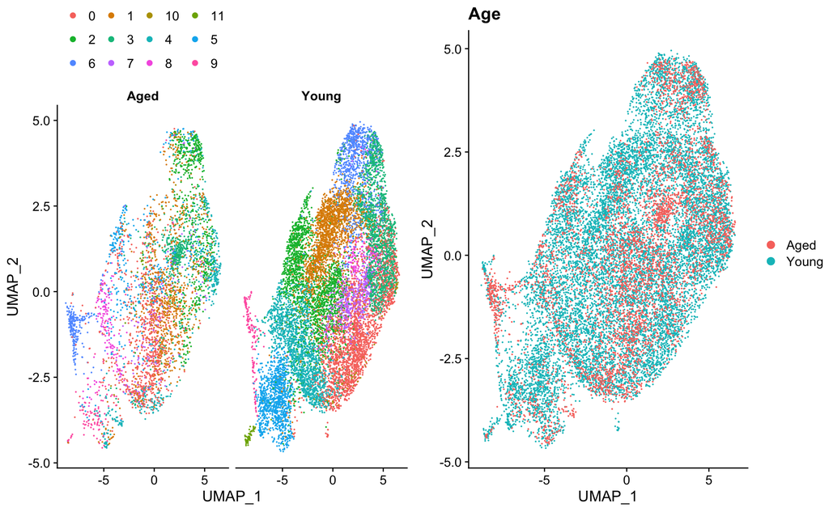

```r
# Generate UMAP plots and label by cluster and condition to ensure
# integration hasn't introduced any batch effects

plots <- DimPlot(seurat_obj, group.by = "seurat_clusters", split.by = "condition", combine = FALSE)
plots <- lapply(X = plots, FUN = function(x) x + theme(legend.position = "top") + guides(color = guide_legend(nrow = 3,
    byrow = TRUE, override.aes = list(size = 2))))
batch_plot <- DimPlot(seurat_obj, group.by = "condition") + ggtitle("Age")
plots[[2]] <- batch_plot
CombinePlots(plots)
```

### Metaneighbor Analysis

Metaneighbor identifies closeness of clusters based on variable genes. Theoretically, markers from one dataset can be used to identify markers in other datasets.

```r
library(MetaNeighbor)
library(SingleCellExperiment)
# Prepare data for conversion to SingleCellExperiment
metadata <- FetchData(seurat_obj, vars = c("orig.ident", "condition", "seurat_clusters"))
metadata$cluster <- paste0(metadata$condition, "_", metadata$seurat_clusters)
seurat_obj[["cluster"]] <- metadata$cluster
sce_obj <- as.SingleCellExperiment(seurat_obj)

# Run unsupervised metaneighbor based on top variable genes
variable_genes <- variableGenes(sce_obj, exp_labels = sce_obj$condition)
celltype_nv = MetaNeighborUS(var_genes = variable_genes,
dat = sce_obj,
study_id = sce_obj$condition,
cell_type = sce_obj$seurat_clusters, fast_version = TRUE)
```

Representing results as a heatmap of AUROC values.

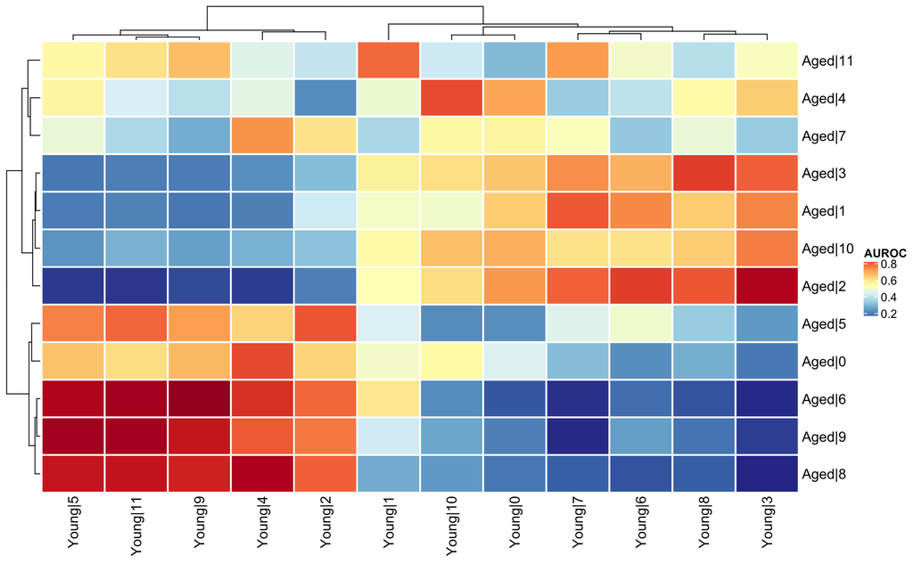

```r
# Plot metaneighbor AUC values as a heatmap
cols = rev(colorRampPalette(RColorBrewer::brewer.pal(11,"RdYlBu"))(100))
breaks = seq(0, 1, length=101)

auroc_matrix <- celltype_nv[paste0("Aged|", as.character(0:11)),
                            paste0("Young|", as.character(0:11))]
auroc_plot <- Heatmap(auroc_matrix, col = cols, name = "AUROC",
                      rect_gp = gpar(col = "white", lwd = 2))
draw(auroc_plot)
```

The heatmap shows we have pairs of clusters from each timepoint that have an AUROC value of 0.8 or greater. These would be clusters that share the greatest similarity.

```r
# Integrate clusters
celltype_df <- as.data.frame(celltype_nv)
celltype_df$ref_cluster <- rownames(celltype_df)
celltype_df <- celltype_df %>% gather(cluster, AUROC, -ref_cluster)

# Remove equal clusters
diff_clusters <- subset(celltype_df, celltype_df$ref_cluster != celltype_df$cluster)

# Separate clusters
diff_clusters <- subset(diff_clusters, startsWith(diff_clusters$ref_cluster, "Young"))
diff_clusters <- subset(diff_clusters, startsWith(diff_clusters$cluster, "Aged"))

# Select clusters that have AUROC of 0.9
top_hits <- topHits(cell_NV = celltype_nv,
dat = sce_obj,
study_id = sce_obj$condition,
cell_type = sce_obj$seurat_clusters,
threshold = 0.9)

print(top_hits)
```

| Study_ID\|Celltype_1 | Study_ID\|Celltype_2 | Mean_AUROC | Match_type |
| --- | --- | --- | --- |
| Young\|9 | Aged\|6 | 0.98 | Reciprocal_top_hit |
| Aged\|6 | Young\|11 | 0.95 | Above_0.9 |
| Young\|5 | Aged\|9 | 0.95 | Reciprocal_top_hit |
| Young\|4 | Aged\|8 | 0.93 | Reciprocal_top_hit |
| Young\|3 | Aged\|2 | 0.93 | Reciprocal_top_hit |
| Young\|8 | Aged\|3 | 0.83 | Reciprocal_top_hit |
| Young\|10 | Aged\|4 | 0.81 | Reciprocal_top_hit |
| Young\|2 | Aged\|5 | 0.80 | Reciprocal_top_hit |
| Young\|7 | Aged\|1 | 0.80 | Reciprocal_top_hit |
| Young\|1 | Aged\|11 | 0.77 | Reciprocal_top_hit |

```r
top_hits <- top_hits %>% filter(Match_type == "Reciprocal_top_hit" &
                                  Mean_AUROC > 0.8)
top_hits <- top_hits %>% mutate(Common = 1:nrow(top_hits))
colnames(top_hits) <- c("Young", "Aged", "Mean_AUROC", "Match_type", "Common")
top_hits$Young <- gsub("^Young[|]", "", top_hits$Young)
top_hits$Aged <- gsub("^Aged[|]", "", top_hits$Aged)

print(top_hits)
```

| Young | Aged | Mean_AUROC | Match_type | Common |
| --- | --- | --- | --- | --- |
| 9 | 6 | 0.98 | Reciprocal_top_hit | 1 |
| 5 | 9 | 0.95 | Reciprocal_top_hit | 2 |
| 4 | 8 | 0.93 | Reciprocal_top_hit | 3 |
| 3 | 2 | 0.93 | Reciprocal_top_hit | 4 |
| 8 | 3 | 0.83 | Reciprocal_top_hit | 5 |
| 10 | 4 | 0.81 | Reciprocal_top_hit | 6 |

# Generate new cluster labels

```r
# Extract metadata
metadata <- FetchData(seurat_obj, vars = c("condition", "seurat_clusters"))

# Need to tally cell counts so we can figure out which cluster is the largest,
# and then count them accordingly
countCommonClusterCells <- function(x){
  control_count <- nrow(metadata[which(metadata$condition == "Young" & metadata$seurat_clusters == x[["Young"]]), ])
  aged_count <- nrow(metadata[which(metadata$condition == "Aged" & metadata$seurat_clusters == x[["Aged"]]), ])
  return(control_count + aged_count)
}

common_cluster_counts <- apply(top_hits, 1, countCommonClusterCells)
top_hits$Counts <- common_cluster_counts
top_hits$Common <- 1:nrow(top_hits)

# Add column
metadata$cluster <- "Common_0"

# Assign clusters for each row
for (n in 1:nrow(top_hits)){
  x <- top_hits[n, ]
  control_cluster <- x$Young
  aged_cluster <- x$Aged
  new_cluster <- paste0("Common_", x$Common)

  metadata[which(metadata$condition == "Young" & metadata$seurat_clusters == control_cluster), "cluster"] <- new_cluster
  metadata[which(metadata$condition == "Aged" & metadata$seurat_clusters == aged_cluster), "cluster"] <- new_cluster
}

# If cluster == Common_0, create alternative labels
exclusive_clusters <- subset(metadata, metadata$cluster == "Common_0")

# Count clusters by condition
unique_cluster_counts <- exclusive_clusters %>% group_by(condition, seurat_clusters) %>% summarize(Counts = n())

# Preserve cluster 0
unique_cluster_counts$cluster <- NULL

# Number rows accordingly
unique_cluster_counts <- unique_cluster_counts %>% mutate(cluster = row_number() - 1)

# Create new column label
unique_cluster_counts$cluster <- paste0(unique_cluster_counts$condition, "_", unique_cluster_counts$cluster)

for (n in 1:nrow(unique_cluster_counts)){
  x <- unique_cluster_counts[n, ]
  metadata[which(metadata$condition ==  x[["condition"]] & metadata$seurat_clusters == x[["seurat_clusters"]]), "cluster"] <- x[["cluster"]]
}

# Final cluster counts
cluster_counts <- as.data.frame(table(metadata$cluster))
colnames(cluster_counts) <- c("Cluster", "Cells")
print(cluster_counts)
```

| Cluster | Cells |
| --- | --- |
| Aged_0 | 851 |
| Aged_1 | 815 |
| Aged_2 | 46 |
| Aged_3 | 32 |
| Aged_4 | 410 |
| Aged_5 | 170 |
| Common_1 | 387 |
| Common_2 | 1170 |
| Common_3 | 1811 |
| Common_4 | 2204 |

[output cut: 8 more lines]

```r
seurat_obj[["cluster"]] <- metadata$cluster
Idents(seurat_obj) <- "cluster"
```

## Cluster characterisation

Characterise common clusters using the `FindConservedMarkers` function.

```r
# Find markers for each cluster
integrated_markers <- FindAllMarkers(seurat_obj, test.use = "bimod")

# Find conserved markers
conserved_markers1 <- FindConservedMarkers(seurat_obj,
                                           ident.1 = "Common_1",
                                           grouping.var = "condition",
                                           verbose = FALSE)

conserved_markers2 <- FindConservedMarkers(seurat_obj, ident.1 = "Common_2",
                                           grouping.var = "condition",
                                           verbose = FALSE)

conserved_markers3 <- FindConservedMarkers(seurat_obj,
                                           ident.1 = "Common_3",
                                           grouping.var = "condition",
                                           verbose = FALSE)

conserved_markers4 <- FindConservedMarkers(seurat_obj,
                                           ident.1 = "Common_4",
                                           grouping.var = "condition",
                                           verbose = FALSE)

conserved_markers5 <- FindConservedMarkers(seurat_obj,
                                           ident.1 = "Common_5",
                                           grouping.var = "condition",
                                           verbose = FALSE)

conserved_markers6 <- FindConservedMarkers(seurat_obj,
                                           ident.1 = "Common_6",
                                           grouping.var = "condition",
                                           verbose = FALSE)

# Find differentially expressed genes between age within clusters
for (cluster in as.character(1:6)){
  cluster_id <- paste0("Common_", cluster)
  condition_de_results <- FindMarkers(seurat_obj, ident.1 = "Aged",
                              ident.2 = "Young",
                              group.by = "condition",
                              subset.ident = cluster_id,
                              test.use = "bimod")
  condition_de_results <- condition_de_results %>% rownames_to_column("gene_id")
}
```